# PPCA0026: Métodos Computacionais Intensivos para Mineração de Dados

Semana 2, Parte 2: Visualização Multivariada & Conceitos de Exploração Interativa

Author

Affiliation

Prof. Donald M. Pianto

Universidade de Brasília (UnB) - Programa de Pós-Graduação em Computação Aplicada (PPCA)

Published

June 6, 2025

## Objetivos da Aula

- Explorar técnicas para visualização de dados multivariados.
- Discutir estratégias para lidar com overplotting em grandes conjuntos de dados.
- Introduzir os conceitos fundamentais de visualização interativa.
- Apresentar ferramentas em R para criar visualizações interativas.

## Visualizando Dados Multivariados

Quando temos mais de duas ou três variáveis, como podemos visualizá-las efetivamente?

### Análise de Componentes Principais (PCA) para Visualização

- **Conceito:** PCA é uma técnica de redução de dimensionalidade que transforma os dados em um novo conjunto de variáveis (componentes principais) não correlacionadas, ordenadas pela variância que explicam.
- **Utilidade para Visualização:**
  - Plotar os dois ou três primeiros componentes principais (PC1 vs PC2, ou PC1 vs PC2 vs PC3) permite visualizar a estrutura de dados de alta dimensão em um espaço de baixa dimensão.
  - Ajuda a identificar clusters, outliers e as direções de maior variação nos dados.
- **Em R (com `stats::prcomp` e `ggplot2`):**

```r
library(ggplot2)
data(iris)

# Realiza PCA nas colunas numéricas (1 a 4)
pca_result <- prcomp(iris[,1:4], center = TRUE, scale. = TRUE)

# Cria um data frame com os componentes principais e a variável Species
pca_data <- data.frame(pca_result$x[,1:2], Species = iris$Species) # Usando PC1 e PC2

# Plota PC1 vs PC2
ggplot(pca_data, aes(x = PC1, y = PC2, color = Species, shape = Species)) +
  geom_point(size = 3, alpha = 0.7) +
  labs(title = "Visualização PCA do Dataset Iris (PC1 vs PC2)",
       x = paste0("Componente Principal 1 (", round(summary(pca_result)$importance[2,1]*100, 1), "%)"),
       y = paste0("Componente Principal 2 (", round(summary(pca_result)$importance[2,2]*100, 1), "%)")) +
  theme_minimal() +
  stat_ellipse(aes(group = Species), type = "norm", level = 0.95, linetype = 2, alpha=0.5) # Adiciona elipses de confiança
```

#### PCA (continuação)

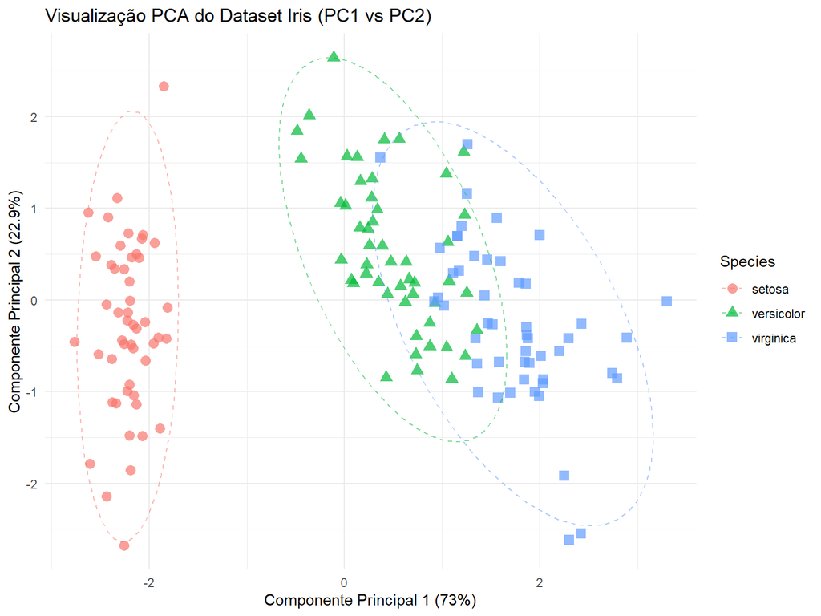

Visualização dos dois primeiros Componentes Principais do dataset iris.

#### Outras técnicas de redução (extração)

- **Outras Técnicas de Extração de Features:** PCA é apenas uma de várias técnicas. Métodos como Independent Component Analysis (ICA), Linear Discriminant Analysis (LDA), t-SNE (para visualização), e Autoencoders também podem ser usados para extrair features ou reduzir dimensionalidade. Para uma visão geral, consulte o material `Feature Extraction Techniques.pdf`.

### Matrizes de Gráficos de Dispersão (SPLOMs)

- **Conceito:** Uma matriz de gráficos de dispersão, onde cada célula (i, j) mostra o scatterplot da variável `i` vs. variável `j`. A diagonal pode mostrar histogramas ou estimativas de densidade de cada variável.
- **Utilidade:** Permite visualizar todas as relações par a par em um único display. Útil para identificar correlações, clusters e outliers em múltiplas dimensões.
- **Referência Teórica:** `classicas-14.pdf`
- **Em R (com `GGally`):**

```r
library(GGally)
data(iris)
ggpairs(iris, columns = 1:4, aes(color = Species, alpha = 0.6)) +
  labs(title = "SPLOM do Dataset Iris")
```

#### Matrizes de Gráficos de Dispersão (SPLOMs) (cont)

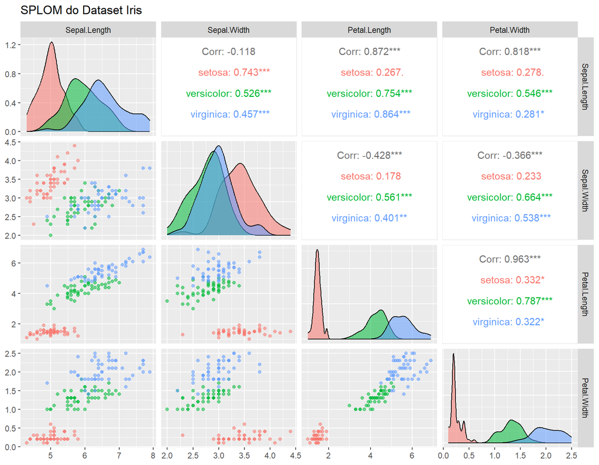

Exemplo de Matriz de Gráficos de Dispersão (SPLOM) com o dataset iris.

### Coordenadas Paralelas

- **Conceito:** Cada variável é representada por um eixo vertical. Uma observação é uma linha (polilinha) que cruza cada eixo no valor correspondente da variável.
- **Utilidade:** Boa para identificar clusters, relações (especialmente inversas entre eixos adjacentes) e padrões em dados de alta dimensionalidade. A ordem dos eixos é importante.
- **Referência Teórica:** `classicas-25.pdf` a `classicas-34.pdf` (incluindo variantes)
- **Em R (com `GGally`):**

```r
library(GGally)
data(iris)
ggparcoord(iris,
           columns = 1:4,
           groupColumn = "Species",
           scale = "uniminmax", # Escala para [0,1] por variável
           alphaLines = 0.5
           ) +
  labs(title = "Coordenadas Paralelas do Dataset Iris") +
  theme_minimal()
```

#### Coordenadas Paralelas (continuação)

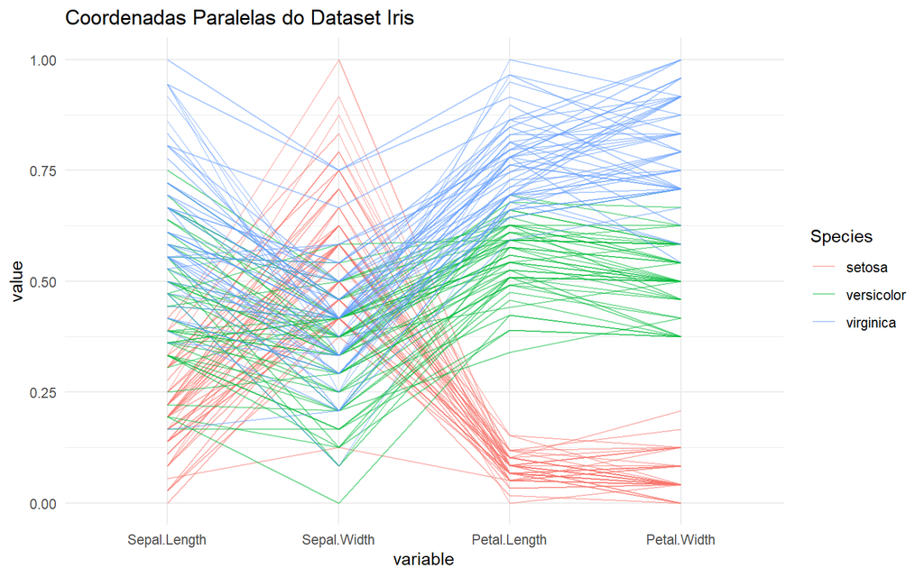

Exemplo de Coordenadas Paralelas com o dataset iris.

### Mapas de Calor (Heatmaps)

- **Conceito:** Representação gráfica de uma matriz de dados onde os valores são representados por cores.
- **Utilidade:** Excelente para visualizar a magnitude de fenômenos em duas dimensões (e.g., matrizes de correlação, expressão gênica, dados tabulares). A reordenação de linhas/colunas (clustering) pode revelar padrões.
- **Referência Teórica:** `classicas-43.pdf`
- **Em R (com `ggplot2`):**

```r
library(ggplot2)
library(reshape2) # Para a função melt
data(mtcars)

cor_matrix <- round(cor(mtcars[, c("mpg", "cyl", "disp", "hp", "wt", "qsec")]), 2)
melted_cormat <- melt(cor_matrix)

ggplot(data = melted_cormat, aes(x = Var1, y = Var2, fill = value)) +
  geom_tile(color = "white") + # Adiciona bordas brancas
  scale_fill_gradient2(low = "blue", high = "red", mid = "white",
                       midpoint = 0, limit = c(-1,1), space = "Lab",
                       name="Correlação") +
  theme_minimal() +
  theme(axis.text.x = element_text(angle = 45, vjust = 1, hjust = 1)) +
  coord_fixed() + # Garante que as células sejam quadradas
  geom_text(aes(label = value), color = "black", size = 3) + # Adiciona valores
  labs(title = "Mapa de Calor das Correlações (mtcars)")
```

#### Mapas de Calor (Continuação)

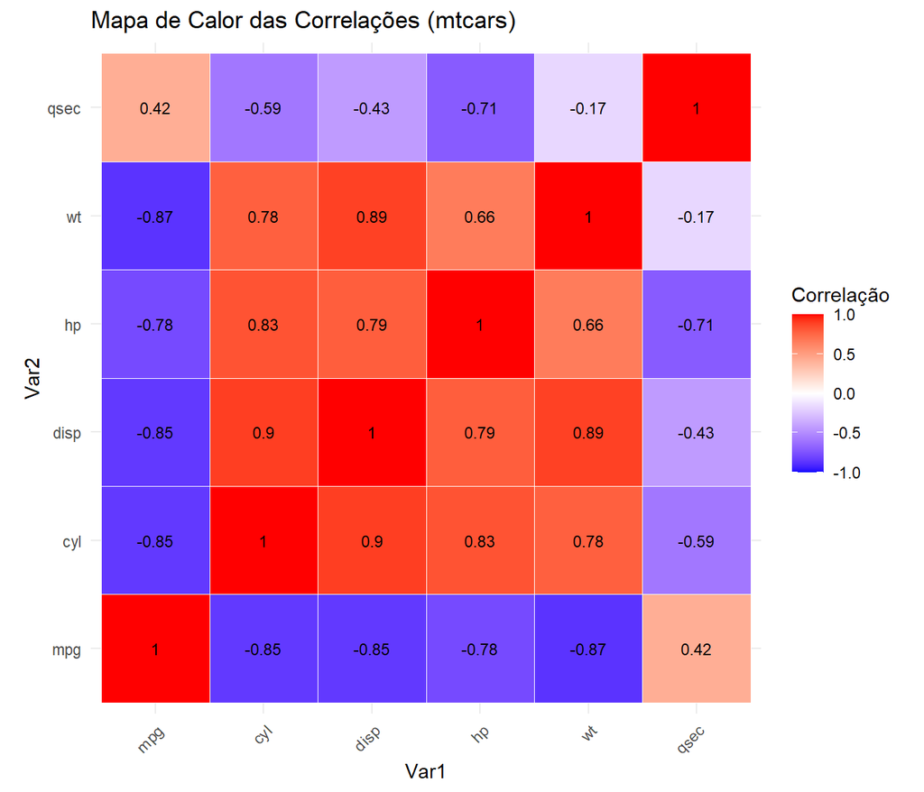

Exemplo de Mapa de Calor da matriz de correlação do dataset mtcars.

## Lidando com Overplotting

Em grandes conjuntos de dados, muitos pontos podem se sobrepor, obscurecendo padrões.

### Estratégias para Overplotting

- **Transparência (Alpha Blending):**
  - Pontos semi-transparentes revelam regiões de alta densidade.
  - Em `ggplot2`: `geom_point(alpha = 0.1)`
- **Jittering:**
  - Adiciona uma pequena quantidade de ruído aleatório à posição dos pontos.
  - Útil para dados categóricos ou discretos onde pontos se sobrepõem perfeitamente.
  - Em `ggplot2`: `geom_jitter(width = 0.1, height = 0.1)`
- **Binning / Agregação:**
  - **2D Histogramas / Heatmaps de Densidade:** Agrupa pontos em bins 2D e mapeia a contagem/densidade para cor.
  - Em `ggplot2`: `geom_bin2d()`, `geom_hex()`, `stat_density_2d(aes(fill = ..level..), geom = "polygon")`
- **Amostragem (Sampling):**
  - Plotar um subconjunto aleatório dos dados se o dataset for muito grande.
- **Referências:** `02-Robustez-e-Graficos.pdf` (p.27 para binning), `classicas.pdf` (menciona agregação em contextos como coordenadas paralelas hierárquicas, p.30).

#### Exemplo de Overplotting

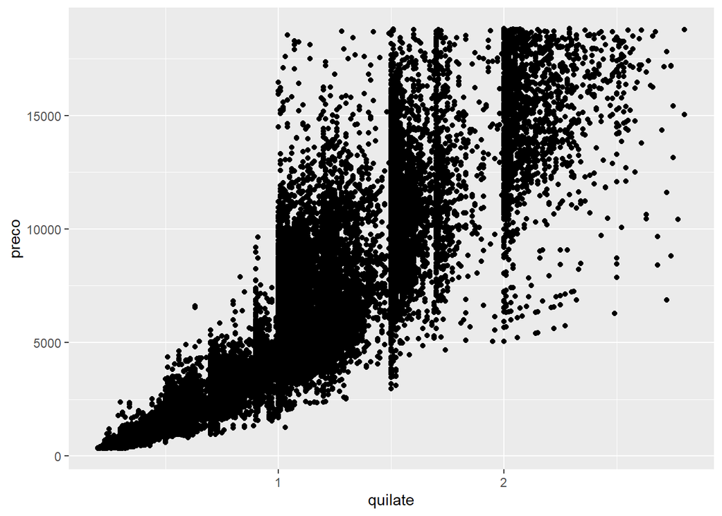

```r
menores_diamantes <- diamante |>
  filter(quilate < 3)

ggplot(menores_diamantes, aes(x = quilate, y = preco)) +
  geom_point()
```

#### Resolvendo Overplotting

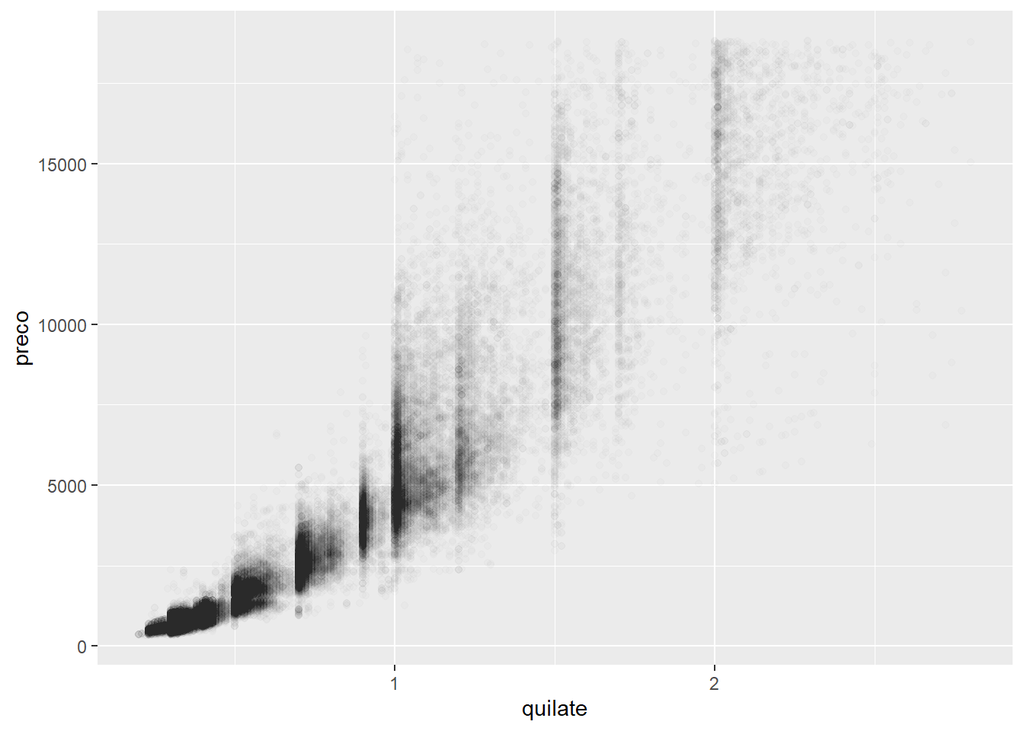

```r
ggplot(menores_diamantes, aes(x = quilate, y = preco)) +
  geom_point(alpha = 1 / 100)
```

## Introdução à Visualização Interativa

Permitir que o usuário explore os dados dinamicamente.

### O Pipeline de Análise Visual

- A interação do usuário é um loop de feedback em todas as etapas: Transformação de Dados $\rightarrow$ Mapeamentos Visuais $\rightarrow$ Transformações de Visualização.
- **Referência:** `InteractionVis-3.pdf`

### Conceitos Chave de Interação

(Baseado em Shneiderman e Yi et al., como em `InteractionVis.pdf`)

- **“Overview first, zoom and filter, then details-on-demand”** (Shneiderman).
  - **Overview:** Ganhar uma visão geral da coleção inteira (`InteractionVis-50.pdf`).
  - **Zoom:** Ampliar itens de interesse (`InteractionVis-37.pdf`, `InteractionVis-50.pdf`).
    - **Zoom Geométrico vs. Semântico:** Alterar tamanho vs. alterar representação (`InteractionVis-34.pdf`).
  - **Filter:** Remover itens desinteressantes (`InteractionVis-50.pdf`, `InteractionVis-54.pdf`).
    - Ex: **Dynamic Queries** (`InteractionVis-9.pdf` a `InteractionVis-16.pdf`).
  - **Details-on-Demand:** Selecionar um item/grupo para obter mais informações (`InteractionVis-50.pdf`).
    - Ex: Tooltips (passar o mouse sobre um ponto para ver seus valores).

### Mais Técnicas de Interação

- **Linking & Brushing (Seleção Conectada):**
  - Selecionar (brushing) um subconjunto de dados em uma visualização e ver os mesmos itens destacados (linking) em outras visualizações coordenadas.
  - **Referência:** `InteractionVis-6.pdf` a `InteractionVis-8.pdf`.
- **Focus + Context:**
  - Mostrar uma área de interesse em detalhe (foco) enquanto mantém uma visão geral do restante dos dados (contexto).
  - Ex: Fisheye views (`InteractionVis-19.pdf`), Bifocal Display (`InteractionVis-27.pdf`), Hyperbolic Trees (`InteractionVis-28.pdf`).
- **Reconfigure:** Mostrar um arranjo diferente (e.g., mudar ordem dos eixos em coordenadas paralelas). (`InteractionVis-54.pdf`)
- **Encode:** Mostrar uma representação diferente (e.g., mudar de scatterplot para heatmap). (`InteractionVis-54.pdf`)

## Ferramentas em R para Visualização Interativa

### `plotly` para R

- **Conceito:** Cria gráficos interativos baseados em D3.js, com suporte para WebGL.
- **`ggplotly()`:** Converte gráficos `ggplot2` estáticos em interativos com uma única função.
  - Adiciona tooltips, zoom, pan, seleção de legenda por padrão.
- **Sintaxe Nativa `plotly`:** `plot_ly()` para criar gráficos diretamente.
- **Referência Principal:** “Interactive web-based data visualization with R, plotly, and shiny” by Carson Sievert (https://plotly-r.com/).
  - Capítulos iniciais são ótimos para começar com `ggplotly()`.

```r
# library(ggplot2)
# library(plotly)
# data(iris)
#
# p_static <- ggplot(iris, aes(x = Sepal.Length, y = Petal.Length, color = Species)) +
#   geom_point() +
#   labs(title = "Gráfico Estático ggplot2")
#
# print(p_static) # Mostra o gráfico estático
#
# p_interactive <- ggplotly(p_static)
# print(p_interactive) # Mostra o gráfico interativo (no RStudio Viewer ou navegador)
```

*Execute este código no RStudio para ver a interatividade.*

### `Shiny` para Dashboards e Aplicações Web

- **Conceito:** Framework R para construir aplicações web interativas e dashboards diretamente do R, sem necessidade de HTML/CSS/JavaScript (inicialmente).
- **Componentes:**
  - `ui.R` (User Interface): Define o layout e a aparência.
  - `server.R` (Server Logic): Define como as entradas do usuário afetam as saídas (plots, tabelas).
- **Utilidade:** Permite criar ferramentas de exploração de dados altamente personalizadas, onde os usuários podem modificar parâmetros, filtrar dados e ver atualizações em tempo real.
- **Referência Principal:** “Mastering Shiny” by Hadley Wickham (https://mastering-shiny.org/).
  - Pode ser mais avançado para este curso, mas é bom conhecer como um próximo passo.

*(Uma demonstração de um App Shiny simples pode ser feita se o tempo permitir).*

### `crosstalk` para Linking entre HTML Widgets

- **Conceito:** Permite que diferentes visualizações HTML (e.g., múltiplos gráficos `plotly`, tabelas `DT`) em uma mesma página web se comuniquem entre si (linking e brushing sem um servidor Shiny completo).
- **Utilidade:** Útil para criar painéis de exploração onde a seleção em um gráfico filtra ou destaca dados em outro.
- **Referência:** Vinhetas do pacote `crosstalk` no CRAN.

## Foco do Laboratório / Atividades Práticas (Semana 2)

- Criar SPLOMs (`GGally::ggpairs`) e Coordenadas Paralelas (`GGally::ggparcoord`) para um dataset.
- Gerar um Heatmap de uma matriz de correlação ou dados tabulares.
- Aplicar técnicas para reduzir overplotting (transparência, jitter) em gráficos de dispersão.
- **Introdução à Interatividade:**
  - Converter um gráfico `ggplot2` existente em um gráfico `plotly` interativo usando `ggplotly()`.
  - Explorar as interações padrão (hover, zoom, pan).
  - (Opcional, se o tempo permitir) Criar um gráfico `plotly` nativo simples.

## Conclusão e Próximos Passos

- A visualização multivariada e interativa são ferramentas poderosas para a exploração de dados complexos.
- R, com pacotes como `GGally`, `plotly`, e `shiny`, oferece um ecossistema rico para criar essas visualizações.
- **Próxima Semana (Semana 3):** Métodos de Reamostragem I: Bootstrap & Jackknife.